# mrp_build

Dewi Lestari Amaliah - 31251587

03/08/2021

## Using mrpkit to build model

1. Base model: age, race_ethnicity (collapsed race_ethnicity), state, gender. Outcome would be vote (voted_pres_16)
2. Additional predictor: Base model + education
3. Model with additional level: age, race_ethnicity (original race_ethnicity), state, gender. Outcome would be vote (voted_pres_16)
4. Model 2 with 2 other outcome , i.e., intent(intent_pres_16) and party identity (pid3).

```r
# read the data
cces <- read_rds(here::here("case_study/data/cces_use.rds"))
acs <- read_rds(here::here("case_study/data/acs_use_wrangled.rds"))
```

## Descriptive of outcome variables

```r
get_ct <- function(x){
    cces %>% group_by({{x}}) %>%
    count() %>%
    mutate(percentage = round(n/nrow(cces)*100,2)) %>%
    select(-n)
    }

voted_ct <- get_ct(voted_pres_16)
intent_ct <- get_ct(intent_pres_16)
party_id_ct <- get_ct(pid3_leaner)
gender_ct <- get_ct(gender)
race_ct <- get_ct(race)
age_ct <- get_ct(age)
education_ct <- get_ct(educ)
```

```r
knitr::kables(
  list(
    knitr::kable(voted_ct,
                 caption = "For whom did you vote for President of the United States?",
                 col.names = c("response", "%")),
    knitr::kable(intent_ct,
                 caption = "Which candidate did you prefer for President of the United States?",
                 col.names = c("response", "%")),
    knitr::kable(party_id_ct,
                 caption = "Party identity, codes self-identified Independents in pid3 who expressed leaning towards a party in pid7.",
                 col.names = c("response", "%"))),
  caption = "Percentage of each answer in CCES 2016. This question will be the MRP models' outcome in this case study. Since the model is binary, these answer will be yes/no in the context of vote for Trump.") %>%
  kable_styling()
```

Percentage of each answer in CCES 2016. This question will be the MRP models’ outcome in this case study. Since the model is binary, these answer will be yes/no in the context of vote for Trump.

For whom did you vote for President of the United States?

| response | % |
| --- | --- |
| Hilary Clinton | 34.27 |
| Donald Trump | 29.03 |
| Other / Someone Else | 6.26 |
| Did Not Vote | 0.13 |
| Not Sure / Don’t Recall | 0.35 |
| NA | 29.97 |

Which candidate did you prefer for President of the United States?

| response | % |
| --- | --- |
| Donald Trump (Republican) | 29.76 |
| Hillary Clinton (Democrat) | 42.57 |
| Gary Johnson (Libertarian) | 4.87 |
| Jill Stein (Green) | 2.17 |
| Other | 2.91 |
| I Won’t Vote in this Election | 5.13 |
| I’m Not Sure | 10.12 |
| NA | 2.47 |

Party identity, codes self-identified Independents in pid3 who expressed leaning towards a party in pid7.

| response | % |
| --- | --- |
| Democrat (Including Leaners) | 48.20 |
| Republican (Including Leaners) | 32.27 |
| Independent (Excluding Leaners) | 16.24 |
| Not Sure | 3.20 |
| NA | 0.08 |

```r
prop.table(table(cces$pid3_leaner,cces$pid3)) %>%
  kable() %>%
  kable_styling()
```

|  | Democrat | Republican | Independent | Other | Not Sure |
| --- | --- | --- | --- | --- | --- |
| Democrat (Including Leaners) | 0.3852601 | 0.0000155 | 0.0828711 | 0.0073746 | 0.0069098 |
| Republican (Including Leaners) | 0.0000155 | 0.2369008 | 0.0697642 | 0.0113253 | 0.0049732 |
| Independent (Excluding Leaners) | 0.0000155 | 0.0000000 | 0.1214793 | 0.0174139 | 0.0236575 |
| Not Sure | 0.0000155 | 0.0000000 | 0.0083196 | 0.0007282 | 0.0229604 |

```r
prop.table(table(cces$pid3_leaner,cces$pid7)) %>%
  kable() %>%
  kable_styling()
```

|  | NA | Strong Democrat | Not Very Strong Democrat | Lean Democrat | Independent | Lean Republican | Not Very Strong Republican | Strong Republican | Not Sure |
| --- | --- | --- | --- | --- | --- | --- | --- | --- | --- |
| Democrat (Including Leaners) | 0 | 0.2517739 | 0.1335172 | 0.09714 | 0.0000000 | 0.0000000 | 0.0000000 | 0.0000000 | 0.0000000 |
| Republican (Including Leaners) | 0 | 0.0000000 | 0.0000000 | 0.00000 | 0.0000000 | 0.0860472 | 0.1055681 | 0.1313637 | 0.0000000 |
| Independent (Excluding Leaners) | 0 | 0.0000000 | 0.0000000 | 0.00000 | 0.1625662 | 0.0000000 | 0.0000000 | 0.0000000 | 0.0000000 |
| Not Sure | 0 | 0.0000000 | 0.0000000 | 0.00000 | 0.0000000 | 0.0000000 | 0.0000000 | 0.0000000 | 0.0320237 |

## Create SurveyData object for the cces and acs data

```r
# pre-process the cces data for base model
cces_mrp <- cces %>%
  # rename variable as mrpkit workflow
  rename(wt = weight) %>%
  # mutate the outcome which is vote for Donald Trump (yes/no) in post vote
  # mutate the outcome which is vote for Donald Trump (yes/no) in early vote
  # mutate the outcome which is identified as Republican (yes) or no
  mutate(
    vote = as.factor(ifelse(voted_pres_16 == "Donald Trump", "yes", "no")),
    intent = as.factor(ifelse(intent_pres_16 == "Donald Trump (Republican)", "yes", "no")),
    party = as.factor(ifelse(pid3_leaner == "Republican (Including Leaners)", "Republican", "not Republican"))
    )

#### CREATE SURVEYDATA OBJECT
# create survey data object for the survey data
cces_data_obj <- SurveyData$new(
  data = cces_mrp,
  questions = list(age = "Respondent's age group",
                   state = "State",
                   race_ethnicity_collp = "Respondent's race/ethnicity collapsed Native American, Middle Eastern, and Other to Other",
                   race = "Respondent's race/ethnicity original level",
                   gender = "Respondent's gender",
                   educ = "Respondent's education",
                   vote = "Whether the respondent vote for Donald Trump in 2016 Presidential vote (Post)",
                   intent = "Whether the respondent intent to vote for Donald Trump in 2016 Presidential vote",
                   party = "Whether the respondent identify him/herself as Republican or not"),
  responses = list(age = levels(cces_mrp$age),
                   state = levels(cces_mrp$state),
                   race_ethnicity_collp = levels(cces_mrp$race_ethnicity_collp),
                   race = levels(cces_mrp$race),
                   gender = levels(cces_mrp$gender),
                   educ = levels(cces_mrp$educ),
                   vote = c("no", "yes"),
                   intent = c("no", "yes"),
                   party = c("Republican", "not Republican")),
 weights = "wt")
# this step: 0.039 sec elapsed


# pre-process the acs data for base model
acs_mrp <- acs %>%
  # filter out the respondents whose age < 18 years because they are not in the scope of CCES survey?
  filter(age != "Less than 18 years") %>%
  select(state, wt, age, sex, race_ethnicity, race_ethnicity_collps, educ_collps)

# drop unused level in age variable
acs_mrp$age <- droplevels(acs_mrp$age)

# create survey data object for the post-stratification data
acs_data <- SurveyData$new(
  data = acs_mrp,
  questions = list(age = "Respondent's age group",
                   state = "State",
                   sex = "Respondent's gender",
                   race_ethnicity_collps = "Respondent's race/ethnicity recoded",
                   race_ethnicity = "Respondent's race/ethnicity",
                   educ_collps = "Respondent's highest educational attainment"),
  responses = list(age = levels(acs_mrp$age),
                   state = levels(acs_mrp$state),
                   sex = levels(acs_mrp$sex),
                   race_ethnicity_collps = levels(acs_mrp$race_ethnicity_collps),
                   race_ethnicity = levels(acs_mrp$race_ethnicity),
                   educ_collps = levels(acs_mrp$educ_collps)),
  weights = "wt"
)
# this step: 0.641 sec elapsed

# print the object
# acs_data$print()
# this step: 58.992 sec elapsed
```

```r
with(cces, prop.table(table(pid3_leaner, voted_pres_16), 2))
```

```
##                                  voted_pres_16
## pid3_leaner                       Hilary Clinton Donald Trump
##   Democrat (Including Leaners)        0.87700583   0.07907796
##   Republican (Including Leaners)      0.03991321   0.75524252
##   Independent (Excluding Leaners)     0.07304615   0.15175284
##   Not Sure                            0.01003481   0.01392668
##                                  voted_pres_16
## pid3_leaner                       Other / Someone Else Did Not Vote
##   Democrat (Including Leaners)              0.27112763   0.22222222
##   Republican (Including Leaners)            0.30904585   0.51851852
##   Independent (Excluding Leaners)           0.39603470   0.23456790
##   Not Sure                                  0.02379182   0.02469136
##                                  voted_pres_16
## pid3_leaner                       Not Sure / Don't Recall
##   Democrat (Including Leaners)                 0.29694323
##   Republican (Including Leaners)               0.21834061
##   Independent (Excluding Leaners)              0.29694323
##   Not Sure                                     0.18777293
```

**Note:** 1. Re-check if using the `inputstate` (pre-election state name) or inputstate_post (post-election state name)

## Create QuestionMapping object

Even though we have 3 different outcomes and model with various predictors, we can still do question mapping at once, just like shown as follows:

```r
#### QUESTION MAPPING
q_age <- QuestionMap$new(
  name = "age",
  col_names = c("age", "age"),
  values_map = list(
    "18 to 24 years" = "18-24",
    "25 to 34 years" = "25-34",
    "35 to 44 years" = "35-44",
    "45 to 64 years" = "45-54",
    "45 to 64 years" = "55-64",
    "65 years and over" = "65-74",
    "65 years and over" = "75-89",
    "65 years and over" = "90 years and over"))

q_state <- QuestionMap$new(
  name = "state",
  col_names = c("state", "state"),
  values_map = list(
    "Alabama" = "Alabama",
    "Alaska" = "Alaska",
    "Arizona" = "Arizona",
    "Arkansas" = "Arkansas",
    "California" = "California",
    "Colorado" = "Colorado",
    "Connecticut" = "Connecticut",
    "Delaware" = "Delaware",
    "District of Columbia" = "District of Columbia",
    "Florida" = "Florida",
    "Georgia" = "Georgia",
    "Hawaii" = "Hawaii",
    "Idaho" = "Idaho",
    "Illinois" = "Illinois",
    "Indiana" = "Indiana",
    "Iowa" = "Iowa",
    "Kansas" = "Kansas",
    "Kentucky" = "Kentucky",
    "Louisiana" = "Louisiana",
    "Maine" = "Maine",
    "Maryland" = "Maryland",
    "Massachusetts" = "Massachusetts",
    "Michigan" = "Michigan",
    "Minnesota" = "Minnesota",
    "Mississippi" = "Mississippi",
    "Missouri" = "Missouri",
    "Montana" = "Montana",
    "Nebraska" = "Nebraska",
    "Nevada" = "Nevada",
    "New Hampshire" = "New Hampshire",
    "New Jersey" = "New Jersey",
    "New Mexico" = "New Mexico",
    "New York" = "New York",
    "North Carolina" = "North Carolina",
    "North Dakota" = "North Dakota",
    "Ohio" = "Ohio",
    "Oklahoma" = "Oklahoma",
    "Oregon" = "Oregon",
    "Pennsylvania" = "Pennsylvania",
    "Rhode Island" = "Rhode Island",
    "South Carolina" = "South Carolina",
    "South Dakota" = "South Dakota",
    "Tennessee" = "Tennessee",
    "Texas" = "Texas",
    "Utah" = "Utah",
    "Vermont" = "Vermont",
    "Virginia" = "Virginia",
    "Washington" = "Washington",
    "West Virginia" = "West Virginia",
    "Wisconsin" = "Wisconsin",
    "Wyoming" = "Wyoming"))

q_gender <- QuestionMap$new(
  name = "gender",
  col_names = c("gender", "sex"),
  values_map = list(
    "Male" = "Male",
    "Female" = "Female"))

q_recollapsed <- QuestionMap$new(
  name = "collapsed_re",
  col_names = c("race_ethnicity_collp", "race_ethnicity_collps"),
  values_map = list(
    "Asian" = "Asian alone",
    "Black" = "Black or African American alone",
    "Hispanic" = "Hispanic",
    "Other" = "Other",
    "Other" = "Two or More Races",
    "White" = "White alone"))

q_re <- QuestionMap$new(
  name = "original_re",
  col_names = c("race", "race_ethnicity"),
  values_map = list(
    "Black" = "Black or African American alone",
    "White" = "White alone",
    "Hispanic" = "Hispanic",
    "All Other" = "Some Other Race alone",
    "Native American" = "American Indian and Alaska Native tribes",
    "All Other" = "Two or More Races",
    "Asian" = "Asian alone",
    "Native American" = "American Indian alone",
    "All Other" = "Native Hawaiian and Other Pacific Islander alone",
    "Native American" = "Alaska Native alone"))


q_educ <- QuestionMap$new(
  name = "education",
  col_names = c("educ", "educ_collps"),
  values_map = list(
    "HS or Less" = "No high school",
    "HS or Less" = "Regular high school diploma",
    "Some College" = "Some college",
    "Some College" = "Associate's degree",
    "4-Year" = "Bachelor's degree",
    "Post-Grad" = "Post-graduate"))
```

## Create SurveyMap Object

Just like the previous step, we only create one SurveyMap object here for all of the model

```r
## SURVEY MAPPING STEP
map_model <- SurveyMap$new(sample = cces_data_obj,
                            population = acs_data,
                            q_age,
                            q_state,
                            q_gender,
                            q_recollapsed,
                            q_re,
                            q_educ)

map_model$mapping()
map_model$tabulate()

#saveRDS(map_model, here::here("case_study/results/map_model.rds"))
```

## Model Fitting

```r
# Recheck: Is it okay to map all the variable here even though it is not included in the model?
# This takes a long time to run (26589.7 seconds)

### FIT THE MODEL

# Model 1
fit1 <- map_model$fit(
  fun = brms::brm,
  formula = vote ~ (1|age) + (1|gender) + (1|state) + (1|collapsed_re),
  family = "bernoulli",
  refresh = 100,
  cores = 2,
  backend = "cmdstanr"
)

# Model 2
fit2 <- map_model$fit(
  fun = brms::brm,
  formula = vote ~ (1|age) + (1|gender) + (1|state) + (1|collapsed_re) + (1|education),
  family = "bernoulli",
  refresh = 100,
  cores = 2,
  backend = "cmdstanr"
)

# Model 3
fit3 <- map_model$fit(
  fun = brms::brm,
  formula = vote ~ (1|age) + (1|gender) + (1|state) + (1|original_re),
  family = "bernoulli",
  refresh = 100,
  cores = 2,
  backend = "cmdstanr"
)

# Model 4a
fit4a <- map_model$fit(
  fun = brms::brm,
  formula = intent ~ (1|age) + (1|gender) + (1|state) + (1|collapsed_re) + (1|education),
  family = "bernoulli",
  refresh = 100,
  cores = 2,
  backend = "cmdstanr"
)

# Model 4b
fit4b <- map_model$fit(
  fun = brms::brm,
  formula = party ~ (1|age) + (1|gender) + (1|state) + (1|collapsed_re) + (1|education),
  family = "bernoulli",
  refresh = 100,
  cores = 2,
  backend = "cmdstanr"
)
```

# Predict the population

```r
# read the fit object
fit1 <- readRDS(here::here("case_study/results/fit1.rds"))
fit2 <- readRDS(here::here("case_study/results/fit2.rds"))
fit3 <- readRDS(here::here("case_study/results/fit3.rds"))
fit4a <- readRDS(here::here("case_study/results/fit4a.rds"))
fit4b <- readRDS(here::here("case_study/results/fit4b.rds"))


# predict population
fit1_predict <- fit1$population_predict()
fit2_predict <- fit2$population_predict()
fit3_predict <- fit3$population_predict()
fit4a_predict <- fit4a$population_predict()
fit4b_predict <- fit4b$population_predict()
```

# Predict the outcome by state

```r
# function to get estimation by state
get_state_pred <- function(fit_object, pop_predict){
  temp <- fit_object$aggregate(pop_predict, by = "state")
  temp %>%
    group_by(state) %>%
    summarise(median = median(value),
              lower = quantile(value, 0.025),
              upper = quantile(value, 0.975))
}

# estimation by state fit1
state_est_base <- get_state_pred(fit1, fit1_predict) %>%
  rename(base_model = median,
         lower_base_model = lower,
         upper_base_model = upper)

# estimation by state fit3
state_est_modelb <- get_state_pred(fit2, fit2_predict) %>%
  rename(modelb = median,
         lower_modelb = lower,
         upper_modelb = upper)

# estimation by state fit3
state_est_modelc <- get_state_pred(fit3, fit3_predict) %>%
  rename(modelc = median,
         lower_modelc = lower,
         upper_modelc = upper)

# estimation by state fit4a
state_est_intent <- get_state_pred(fit4a, fit4a_predict) %>%
  rename(intent = median,
         lower_intent = lower,
         upper_intent = upper)

# estimation by state fit4b
state_est_party <- get_state_pred(fit4b, fit4b_predict) %>%
  rename(party = median,
         lower_party = lower,
         upper_party = upper)

# ground truth data
ground_truth <- ddi::g2016 %>%
  select(c(1, 3)) %>%
  rename(truth = pct_djt_voters)

comparison_data <- plyr::join_all(list(ground_truth,
                                 state_est_base,
                                 state_est_modelb,
                                 state_est_modelc,
                                 state_est_intent,
                                 state_est_party),
                            by='state',
                            type='left')
```

# Map of Trump Vote Probability

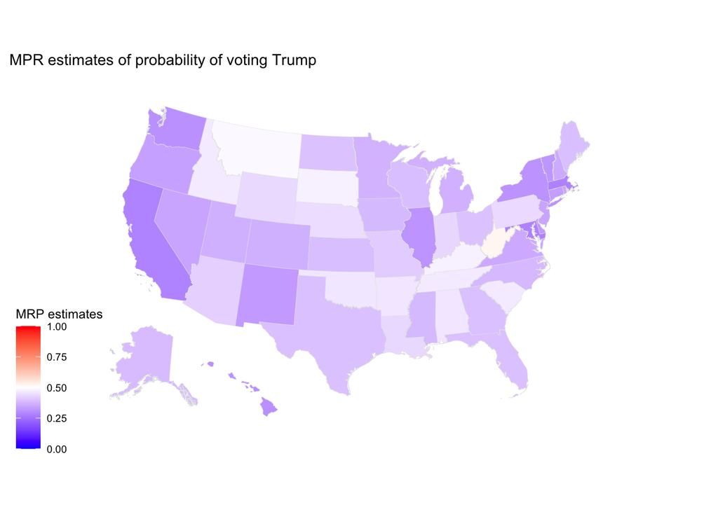

```r
library(scales)
state_estimation_data <- left_join(urbnmapr::states, state_est_base,
                                   by = c("state_name" = "state"))
ggplot(state_estimation_data,
       aes(long, lat, group = group, fill = base_model)) +
  geom_polygon(color = "gray90", size = 0.1) +
  coord_map(projection = "albers", lat0 = 39, lat1 = 45) +
  scale_fill_gradientn(colors=c("blue","white","red"),
                       values=rescale(c(0,0.5,1)),
   limits=c(0,1)) +
  ggtitle("MPR estimates of probability of voting Trump") +
  theme_map() +
  labs(fill = "MRP estimates")
```

# The scatter plot

```r
# function to get RMSE
get_rmse <- function(vect){
  paste0("RMSE= ", round(rmse(comparison_data$truth, vect), 4))
}

# function to get MAD
get_mad <- function(vect){
  paste0("MAE= ", round(mae(comparison_data$truth, vect), 4))
}

# RMSE of each model
rmse_base <- get_rmse(comparison_data$base_model)
rmse_modelb <- get_rmse(comparison_data$modelb)
rmse_modelc <- get_rmse(comparison_data$modelc)
rmse_intent <- get_rmse(comparison_data$intent)
rmse_party <- get_rmse(comparison_data$party)

# MAD of each model
mad_base <- get_mad(comparison_data$base_model)
mad_modelb <- get_mad(comparison_data$modelb)
mad_modelc <- get_mad(comparison_data$modelc)
mad_intent <- get_mad(comparison_data$intent)
mad_party <- get_mad(comparison_data$party)
```

# MRP estimates vs ground truth

The common practice

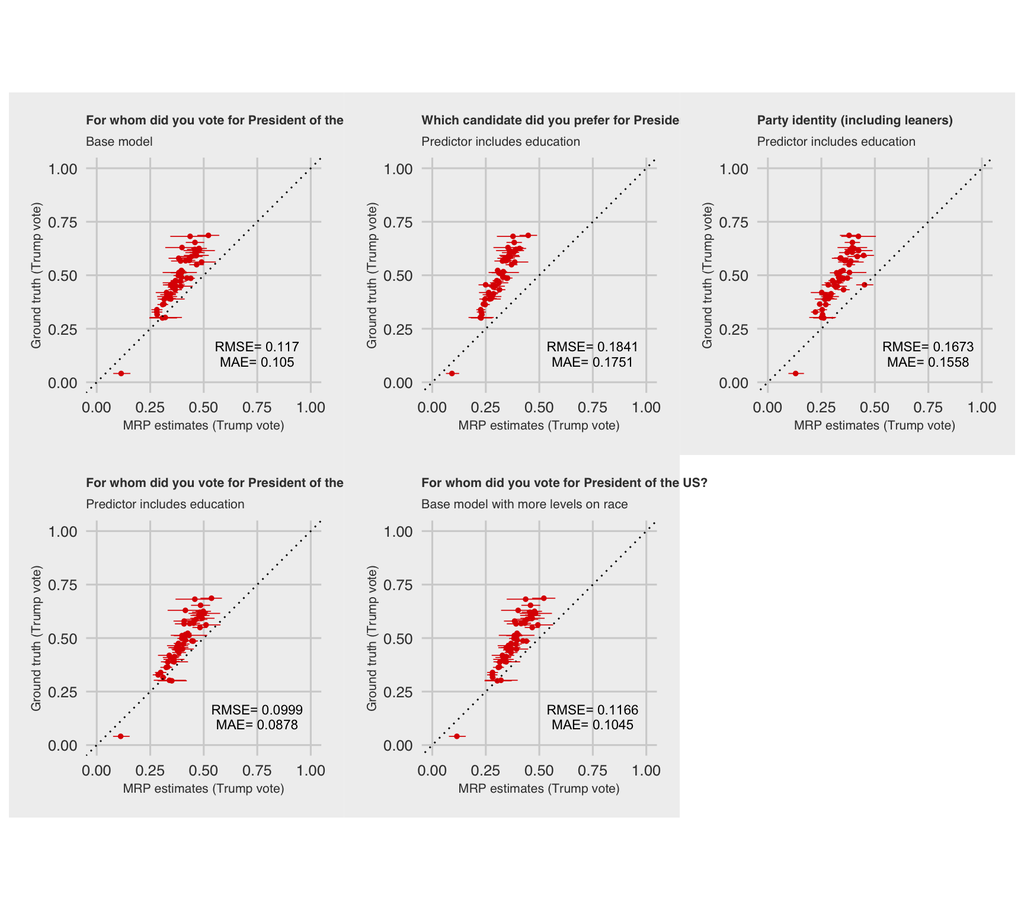

```r
get_scatter_common <- function(x, title, subtitle, lower, upper, rmse, mad){
  ggplot(comparison_data,
         aes(x = x,
             y = truth,
             xmin = lower,
             xmax = upper)) +
    geom_point(color = "#DE0100", size = 1) +
    geom_abline(intercept = 0, linetype = "dotted") +
    geom_errorbarh(color = "#DE0100", size = 0.3) +
    scale_x_continuous(limits = c(0, 1)) +
    scale_y_continuous(limits = c(0, 1)) +
    theme_fivethirtyeight() +
    theme(axis.title = element_text(size = 8),
          plot.title = element_text(size = 8),
          plot.subtitle = element_text(size = 8)) +
    xlab("MRP estimates (Trump vote)") +
    ylab("Ground truth (Trump vote)") +
    theme(aspect.ratio=1) +
    ggtitle( title) +
    labs(subtitle = subtitle) +
  annotate("text", x = 0.75,
           y = 0.10,
           label = rmse,
           vjust = -1,
           size = 3) +
  annotate("text", x = 0.75,
           y = 0.03,
           label = mad,
           vjust = -1,
           size = 3)
}


spc1 <- get_scatter_common(comparison_data$base_model,
                           "For whom did you vote for President of the US?",
                           "Base model",
                           comparison_data$lower_base_model,
                           comparison_data$upper_base_model,
                           rmse_base,
                           mad_base)

spc2 <-  get_scatter_common(comparison_data$modelb,
                           "For whom did you vote for President of the US?",
                           "Predictor includes education",
                           comparison_data$lower_modelb,
                           comparison_data$upper_modelb,
                           rmse_modelb,
                           mad_modelb)

spc3 <- get_scatter_common(comparison_data$modelc,
                           "For whom did you vote for President of the US?",
                           "Base model with more levels on race",
                           comparison_data$lower_modelc,
                           comparison_data$upper_modelc,
                           rmse_modelc,
                           mad_modelc)

spc4a <- get_scatter_common(comparison_data$intent,
                           "Which candidate did you prefer for President?",
                           "Predictor includes education",
                           comparison_data$lower_intent,
                           comparison_data$upper_intent,
                           rmse_intent,
                           mad_intent)

spc4b <- get_scatter_common(comparison_data$party,
                           "Party identity (including leaners)",
                           "Predictor includes education",
                           comparison_data$lower_party,
                           comparison_data$upper_party,
                           rmse_party,
                           mad_party)


spc1 + spc4a + spc4b + spc2 + spc3 + plot_layout(nrow = 2)
```

Doing the other way around for the axis

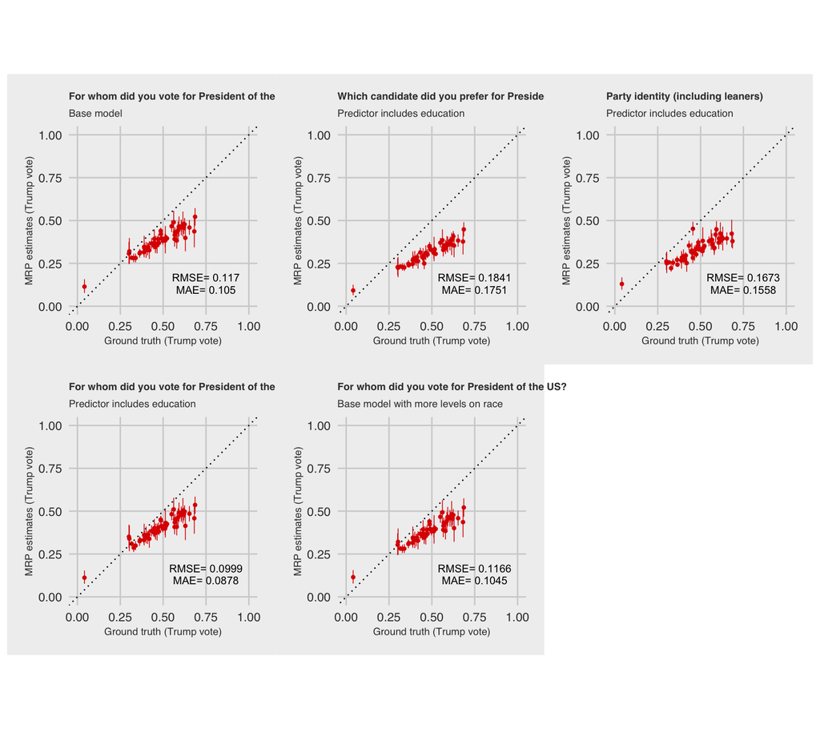

```r
get_scatter <- function(y, title, subtitle, lower, upper, rmse, mad){
  ggplot(comparison_data,
         aes(x = truth,
             y = y,
             ymin = lower,
             ymax = upper)) +
  geom_point(color = "#DE0100", size = 1) +
  geom_abline(intercept = 0, linetype = "dotted") +
  geom_errorbar(color = "#DE0100", size = 0.3) +
  scale_x_continuous(limits = c(0, 1)) +
  scale_y_continuous(limits = c(0, 1)) +
  theme_fivethirtyeight() +
  theme(axis.title = element_text(size = 8),
        plot.title = element_text(size = 8),
        plot.subtitle = element_text(size = 8)) +
  ylab("MRP estimates (Trump vote)") +
  xlab("Ground truth (Trump vote)") +
  theme(aspect.ratio=1) +
  ggtitle(title) +
  labs(subtitle = subtitle) +
  annotate("text", x = 0.75,
           y = 0.10,
           label = rmse,
           vjust = -1,
           size = 3) +
  annotate("text", x = 0.75,
           y = 0.03,
           label = mad,
           vjust = -1,
           size = 3)
}

sp1 <- get_scatter(comparison_data$base_model,
                           "For whom did you vote for President of the US?",
                           "Base model",
                           comparison_data$lower_base_model,
                           comparison_data$upper_base_model,
                           rmse_base,
                           mad_base)

sp2 <-  get_scatter(comparison_data$modelb,
                           "For whom did you vote for President of the US?",
                           "Predictor includes education",
                           comparison_data$lower_modelb,
                           comparison_data$upper_modelb,
                           rmse_modelb,
                           mad_modelb)

sp3 <- get_scatter(comparison_data$modelc,
                           "For whom did you vote for President of the US?",
                           "Base model with more levels on race",
                           comparison_data$lower_modelc,
                           comparison_data$upper_modelc,
                           rmse_modelc,
                           mad_modelc)

sp4a <- get_scatter(comparison_data$intent,
                           "Which candidate did you prefer for President?",
                           "Predictor includes education",
                           comparison_data$lower_intent,
                           comparison_data$upper_intent,
                           rmse_intent,
                           mad_intent)

sp4b <- get_scatter(comparison_data$party,
                           "Party identity (including leaners)",
                           "Predictor includes education",
                           comparison_data$lower_party,
                           comparison_data$upper_party,
                           rmse_party,
                           mad_party)

sp1 + sp4a + sp4b + sp2 + sp3 + plot_layout(nrow = 2)
```

# plot of state against CI

```r
## ---- est-comparison

# filter the na in vote variable
cces_mrp_na_omit <- cces_mrp %>%
  filter(!is.na(vote))

# raw-est

raw_est <- cces_mrp_na_omit %>%
  mutate(vote_bin = ifelse(vote == "yes", 1, 0)) %>%
  group_by(state) %>%
  summarise(mean = mean(vote_bin),
            sd = sqrt(mean(vote_bin)*(1-mean(vote_bin))/length(vote_bin)),
            lower = mean - (1.96*sd/sqrt(length(vote_bin))),
            upper = mean + (1.96*sd/sqrt(length(vote_bin)))) %>%
  select(-sd) %>%
  mutate(est_method = "raw",
         state = as.character(state)) %>%
  arrange(state)

# wtd-est

# create survey object
wtd_est <- svydesign(ids = ~1, weights = ~wt, data = cces_mrp_na_omit)

# calculate wtd estimate who vote for Trump
wtd_mean <- data.frame(svyby(~vote, ~state, wtd_est, svymean)) %>%
  select(voteyes) %>%
  rename(wtd_est = voteyes) %>%
  rownames_to_column("state")
rownames(wtd_mean) <- 1:nrow(wtd_mean)


# calculate confidence interval for voter who vote for Trump
wtd_confint <- data.frame(confint(svyby(~vote, ~state, wtd_est, svymean))) %>%
  rename(lower_wt = X2.5..,
         upper_wt = X97.5..) %>%
  rownames_to_column("state") %>%
  filter(str_detect(state, "voteyes")) %>%
  separate(state, c("state", "vote"), ":") %>%
  select(-vote)

# join mean and confint
wtd_estimates <- left_join(wtd_mean, wtd_confint, by = "state") %>%
  rename(mean = wtd_est,
         lower = lower_wt,
         upper = upper_wt) %>%
  mutate(est_method = "wtd",
         state = as.character(state)) %>%
  arrange(state)

# mrp-est
mrp_estimates <- state_est_modelb %>%
  rename(mean = modelb,
         lower = lower_modelb,
         upper = upper_modelb) %>%
  mutate(est_method = "mrp")


compare_method <- left_join(raw_est, wtd_estimates, by = "state", suffix = c("_raw", "_wtd")) %>%
  left_join(mrp_estimates, by="state") %>%
  rename(mean_mrp = mean,
         lower_mrp = lower,
         upper_mrp = upper) %>%
  select(-est_method_raw, -est_method_wtd, est_method)

# truth
truth <- comparison_data %>%
  select(state, truth)
  # rename(mean = truth) %>%
  # mutate(lower = NA,
  #        upper = NA,
  #        est_method = "truth")

compare_method_df <-  rbind(raw_est, wtd_estimates, mrp_estimates) %>%
  mutate(est_method = factor(est_method, levels = c("raw", "wtd", "mrp"))) %>%
  left_join(truth, by = "state") %>%
  mutate(est_method = factor(est_method, levels = c("truth", "raw", "wtd", "mrp")),
         deviance = truth - mean)


# # est_method_data
#
# est_method_data <- rbind(raw_est, wtd_estimates, mrp_estimates, truth) %>%
#   mutate(est_method = factor(est_method, levels = c("truth", "raw", "wtd", "mrp")))
```

Scatter plot of each estimation method compared to truth

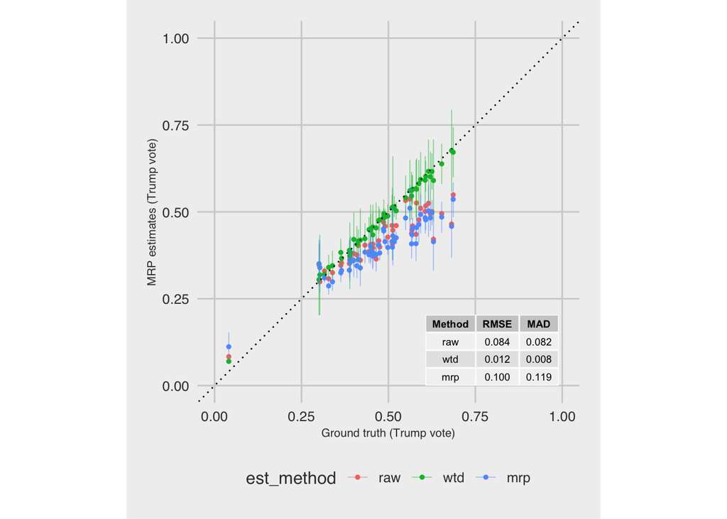

```r
# RMSE of each model
rmse_raw <- round(rmse(truth$truth, raw_est$mean),3)
rmse_mrp <- round(rmse(truth$truth, comparison_data$modelb),3)
rmse_wtd <- round(rmse(truth$truth, wtd_estimates$mean),3)


# MAD of each model
mad_raw <- round(mad(truth$truth, raw_est$mean),3)
mad_mrp <- round(mad(truth$truth, comparison_data$modelb),3)
mad_wtd <- round(mad(truth$truth, wtd_estimates$mean),3)


metrics_method <- tribble(~"Method", ~ "RMSE", ~ "MAD",
                          "raw", rmse_raw, mad_raw,
                          "wtd", rmse_wtd, mad_wtd,
                          "mrp", rmse_mrp, mad_mrp)

ggplot(compare_method_df,
         aes(x = truth,
             y = mean,
             ymin = lower,
             ymax = upper,
             color = est_method)) +
  geom_point(size = 1) +
  geom_abline(intercept = 0, linetype = "dotted") +
  geom_errorbar(size = 0.3,
                alpha = 0.5) +
  annotate(geom = "table",
           x = 0.99,
           y = 0,
           label = list(metrics_method),
           size = 2.5) +
  scale_x_continuous(limits = c(0, 1)) +
  scale_y_continuous(limits = c(0, 1)) +
  theme_fivethirtyeight() +
  theme(axis.title = element_text(size = 8),
        plot.title = element_text(size = 8),
        plot.subtitle = element_text(size = 8)) +
  ylab("MRP estimates (Trump vote)") +
  xlab("Ground truth (Trump vote)") +
  theme(aspect.ratio=1)
```

The plot is:

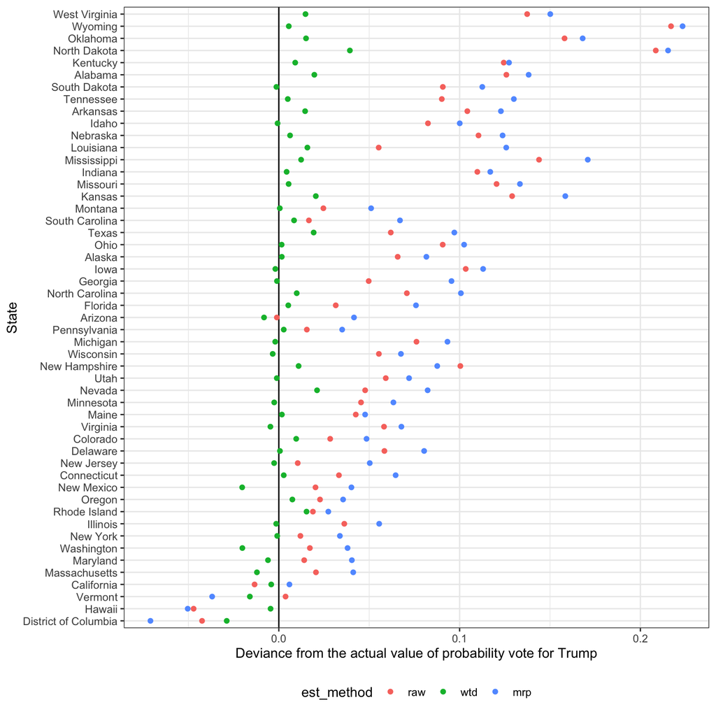

```r
compare_method_df %>%
  mutate(state = as.factor(state),
         state = fct_reorder(state, truth)) %>%
  ggplot(aes(x = deviance, y = state, color = est_method)) +
  geom_vline(xintercept = 0) +
  geom_point() +
  theme_bw() +
  theme(legend.position = "bottom") +
  xlab("Deviance from the actual value of probability vote for Trump") +
  ylab("State")
```

# Violin plot (displaying the effect of using different predictors and levels)

```r
# estimate probability of voting Trump by race
race_est_base <- fit1$aggregate(fit1_predict, by = "original_re") %>%
  mutate(model = "base model")
race_est_mod3 <- fit3$aggregate(fit3_predict, by = "original_re") %>%
  mutate(model = "base model with more levels on race")
comp_race <- rbind(race_est_base, race_est_mod3)


# estimate prob of voting Trump by education
educ_est_base <- fit1$aggregate(fit1_predict, by = "education") %>%
  mutate(model = "base model")
educ_est_mod2 <- fit2$aggregate(fit2_predict, by = "education") %>%
  mutate(model = "base model + education")
comp_educ <- rbind(educ_est_base, educ_est_mod2)

# estimate prob of voting Trump by age
age_est_base <- fit1$aggregate(fit1_predict, by = "age") %>%
  mutate(model = "base model")
age_est_mod2 <- fit2$aggregate(fit2_predict, by = "age") %>%
  mutate(model = "base model + education")
age_est_mod3 <- fit3$aggregate(fit3_predict, by = "age") %>%
  mutate(model = "base model with more levels on race")
comp_age <- rbind(age_est_base, age_est_mod2, age_est_mod3) %>%
  mutate(model = factor(model, levels = c("base model",
                                          "base model + education",
                                          "base model with more levels on race")))
```

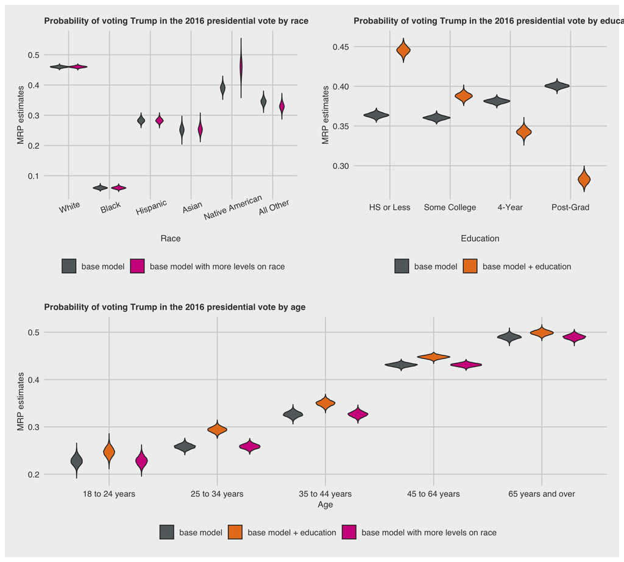

```r
# create the plot for race
p6 <- ggplot(comp_race, aes(x = original_re, y = value, fill = model)) +
  geom_violin() +
  xlab("Race") +
  ylab("MRP estimates") +
  theme_fivethirtyeight() +
  theme(axis.title = element_text(size = 10),
        plot.title = element_text(size = 10),
        axis.text.x = element_text(angle = 20),
        legend.title = element_blank()) +
  ggtitle("Probability of voting Trump in the 2016 presidential vote by race") +
  scale_fill_manual(values = c("#616A6B", "#d01c8b"))

# create the plot for education
p7 <- ggplot(comp_educ, aes(x = education, y = value, fill = model)) +
  geom_violin() +
  xlab("Education") +
  ylab("MRP estimates") +
  theme_fivethirtyeight() +
  theme(axis.title = element_text(size = 10),
        plot.title = element_text(size = 10),
        legend.title = element_blank()) +
  ggtitle("Probability of voting Trump in the 2016 presidential vote by education") +
  scale_fill_manual(values = c("#616A6B", "#E67E22"))

# create the plot for age
p8 <- ggplot(comp_age, aes(x = age, y = value, fill = model)) +
  geom_violin() +
  xlab("Age") +
  ylab("MRP estimates") +
  theme_fivethirtyeight() +
  theme(axis.title = element_text(size = 10),
        plot.title = element_text(size = 10),
        legend.title = element_blank()) +
  ggtitle("Probability of voting Trump in the 2016 presidential vote by age") +
  scale_fill_manual(values = c("#616A6B", "#E67E22", "#d01c8b"))

(p6 | p7)/p8
```

# Performance metrics

## Correlation (practice)

```r
cor_base_intent <- cor(comparison_data$base_model, comparison_data$intent)
cor_base_party <- cor(comparison_data$base_model, comparison_data$party)

com_outcome <- tribble(~ model, ~correlation,
                       "MRP outcome: vote intention", cor_base_intent,
                       "MRP outcome: party identity", cor_base_party)

cp1 <- ggplot(com_outcome, aes(x = correlation, y = model)) +
  geom_point(size = 3, color = "red") +
  geom_hline(yintercept = "MRP outcome: vote intention", linetype = "dotted", color = "#DE0100") +
  geom_hline(yintercept = "MRP outcome: party identity", linetype = "dotted", color = "#DE0100") +
  xlim(0, 1) +
  theme_fivethirtyeight() +
  theme(axis.title = element_text(size = 10),
        plot.title = element_text(size = 9)) +
  xlab("Correlation with base model (vote_pres_16)") +
  ylab("Model") +
  annotate("text", x = com_outcome$correlation[1],
           y = "MRP outcome: vote intention",
           label = round(com_outcome$correlation[1],2),
           vjust = -1) +
  annotate("text", x = com_outcome$correlation[2],
           y = "MRP outcome: party identity",
           label = round(com_outcome$correlation[2],2),
           vjust = -1) +
  ggtitle("Correlation between models with different outcomes (same predictors)")
```

```r
cor_base_modelb <- cor(comparison_data$base_model, comparison_data$modelb)
cor_base_modelc <- cor(comparison_data$base_model, comparison_data$modelc)

com_predictor <- tribble(~ model, ~correlation,
                       "MRP with additional predictor", cor_base_modelb,
                       "MRP with more levels in race", cor_base_modelc)

cp2 <- ggplot(com_predictor, aes(x = correlation, y = model)) +
  geom_point(size = 3, color = "red") +
  geom_hline(yintercept = "MRP with additional predictor", linetype = "dotted", color = "#DE0100") +
  geom_hline(yintercept = "MRP with more levels in race", linetype = "dotted", color = "#DE0100") +
  xlim(0, 1) +
  theme_fivethirtyeight() +
  theme(axis.title = element_text(size = 10),
        plot.title = element_text(size = 9)) +
  xlab("Correlation with base model") +
  ylab("Model") +
  annotate("text", x = com_predictor$correlation[1],
           y = "MRP with additional predictor",
           label = round(com_predictor$correlation[1],2),
           vjust = -1) +
  annotate("text", x = com_predictor$correlation[2],
           y = "MRP with more levels in race",
           label = round(com_predictor$correlation[2],2),
           vjust = -1) +
  ggtitle("Correlation between models with different predictors (same outcome)")
```

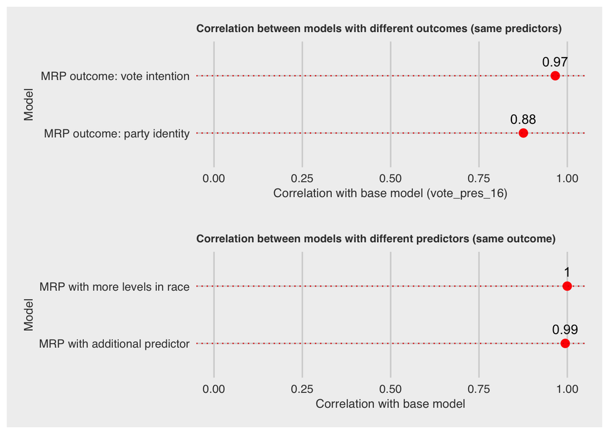

```r
cp1 + cp2 + plot_layout(nrow = 2)
```

Note:

- Correlation: 1-correlation (since higher correlation is better)
- Remove bias from the plot note that mae and bias are the same thing
- There is only one column, so facet is ncol=1, nrow=4
- Order the data in terms of the value so we can see wether the group/level changing
- Add credible interval length (upper-lower), the narrower the better
- For the posterior estimates, use median instead of mean.
- Compare raw vs weighted vs MRP in model with education with states as the level

## Performance metrics

```r
# estimate poststrat function
get_ests_ps <- function(model){
  ests_ps <- cbind(map_model$poststrat_data(), model)
  return(ests_ps)
}

# MRP estimate by state and other variable
get_MRP_ests <- function(est_data, var){
  tmp <- est_data %>%
  pivot_longer(as.character(1:4000),
               names_to = "posterior_draw",
               values_to = "posterior_sample") %>%
  group_by(state, {{var}}, posterior_draw) %>% # Add extra grouping vars here
  summarise(post_strat_ests = sum(posterior_sample*N_j)/sum(N_j))

  return_df <- tmp %>%
  group_by(state, {{var}}) %>%
  summarise(median = median(post_strat_ests),
            lower = quantile(post_strat_ests, 0.025),
            upper = quantile(post_strat_ests, 0.975),
            ci_len = upper - lower)

  return(return_df)
}

# estimate poststrat by model
ests_ps_fit1 <- get_ests_ps(fit1_predict)
ests_ps_fit2 <- get_ests_ps(fit2_predict)
ests_ps_fit3 <- get_ests_ps(fit3_predict)

# MRP estimate by race
mrp_race_state_fit1 <- get_MRP_ests(ests_ps_fit1, original_re)
mrp_race_state_fit3 <- get_MRP_ests(ests_ps_fit3, original_re)

# MRP estimate by education
mrp_educ_state_fit1 <- get_MRP_ests(ests_ps_fit1, education)
mrp_educ_state_fit2 <- get_MRP_ests(ests_ps_fit2, education)

# MRP estimate by age
mrp_age_state_fit1 <- get_MRP_ests(ests_ps_fit1, age)
mrp_age_state_fit2 <- get_MRP_ests(ests_ps_fit2, age)
mrp_age_state_fit3 <- get_MRP_ests(ests_ps_fit3, age)
```

**Metrics of race between base model and model with more levels on race**

```r
# in total
get_metrics <- function(vect, upper, lower){
  cor_adj <- 1 - cor(comparison_data$base_model, vect)
  mae <- mae(comparison_data$base_model, vect)
  rmse <- rmse(comparison_data$base_model, vect)

  metrics <- tribble(~level, ~metrics, ~values,
                    "Statewide", "rmse", rmse,
                    "Statewide", "cor_adj", cor_adj,
                    "Statewide", "mae", mae) %>%
    mutate(level = as.factor(level),
           metrics = as.factor(metrics))

  return(metrics)
}

metrics_fit1_fit3 <- get_metrics(comparison_data$modelc,
                                 comparison_data$upper_modelc,
                                 comparison_data$lower_modelc)

# by level
race_metrics_tmp <- left_join(mrp_race_state_fit1, mrp_race_state_fit3, by = c("state", "original_re"),
                  suffix = c("_fit1", "_fit3")) %>%
  group_by(original_re) %>%
  summarise(cor_adj = 1 - cor(median_fit1, median_fit3),
            mae = mae(median_fit1, median_fit3),
            rmse = rmse(median_fit1, median_fit3)) %>%
  pivot_longer(c(2:4), names_to = "metrics", values_to = "values") %>%
  rename(level = original_re)

race_metrics <- rbind(race_metrics_tmp, metrics_fit1_fit3) %>%
  mutate(metrics = factor(metrics, levels = c("cor_adj", "rmse", "mae", "ci_len")),
         level = factor(level, levels = c("Black", "White", "Hispanic", "Asian", "Native American",
                                          "All Other", "Statewide")))
```

```r
# function to get plot
metrics_label <- c(`cor_adj` = "1-correlation",
                   `rmse` = "Root Mean Square Difference",
                   `mae` = "Mean Absolute Difference")

get_metrics_plot <- function(data, title, subtitle, xlab){
  plot <- data %>%
  mutate(level = reorder(level, values)) %>%
  group_by(metrics, level) %>%
  arrange(desc(values)) %>%
  ungroup() %>%
  mutate(level = factor(paste(level, metrics, sep = "__"),
                       levels = rev(paste(level, metrics, sep = "__")))) %>%
  ggplot(aes(level, values)) +
  geom_segment(aes(xend = level, yend = 0),
               colour = "grey50") +
  geom_point(size = 2) +
  ggtitle(title,
          subtitle = subtitle) +
  facet_wrap(~metrics, scales = "free", ncol = 1,
             labeller = as_labeller(metrics_label)) +
  scale_x_discrete(labels = function(x) gsub("__.+$", "", x)) +
  coord_flip() +
  scale_colour_brewer(palette = "Dark2") +
  theme_bw() +
  xlab(xlab) +
  ylab("Values") +
  theme(panel.grid.major.y = element_blank()) +
  theme(legend.position = "none",
              axis.ticks.y = element_blank(),
        plot.title = element_text(size = 11),
        plot.subtitle = element_text(size = 8))
  return(plot)
}
```

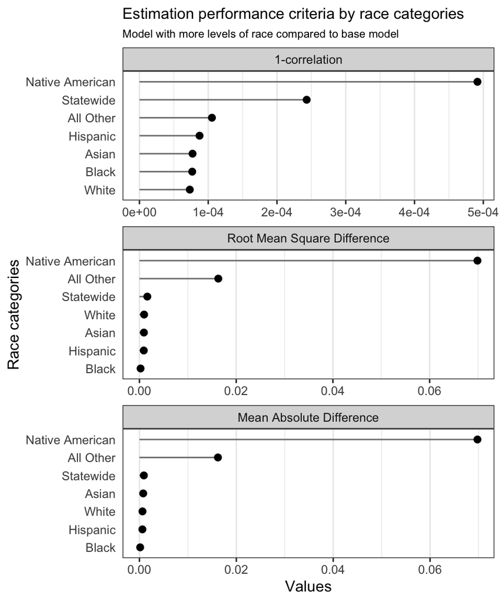

```r
get_metrics_plot(race_metrics,
                 "Estimation performance criteria by race categories",
                 "Model with more levels of race compared to base model",
                 "Race categories")
```

**Metrics of education**

```r
metrics_fit1_fit2 <- get_metrics(comparison_data$modelb,
                                 comparison_data$upper_modelb,
                                 comparison_data$lower_modelb)

educ_metrics_tmp <- left_join(mrp_educ_state_fit1, mrp_educ_state_fit2, by = c("state", "education"),
                  suffix = c("_fit1", "_fit2")) %>%
  group_by(education) %>%
  summarise(cor_adj = 1 - cor(median_fit1, median_fit2),
            mae = mae(median_fit1, median_fit2),
            rmse = rmse(median_fit1, median_fit2)) %>%
  pivot_longer(c(2:4), names_to = "metrics", values_to = "values") %>%
  rename(level = education)

educ_metrics <- rbind(educ_metrics_tmp, metrics_fit1_fit2) %>%
  mutate(metrics = factor(metrics, levels = c("cor_adj", "rmse", "mae")))
```

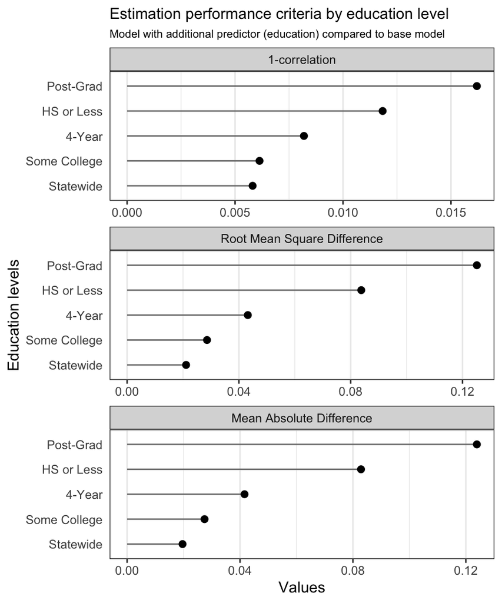

```r
get_metrics_plot(educ_metrics,
                 "Estimation performance criteria by education level",
                 "Model with additional predictor (education) compared to base model",
                 "Education levels")
```

**Correlation of age**

```r
age_metrics_tmp <- left_join(mrp_age_state_fit1, mrp_age_state_fit2, by = c("state", "age"),
                     suffix = c("_fit1", "_fit2")) %>%
  group_by(age) %>%
  summarise(cor_adj = 1 - cor(median_fit1, median_fit2),
            mae = mae(median_fit1, median_fit2),
            rmse = rmse(median_fit1, median_fit2)) %>%
  pivot_longer(c(2:4), names_to = "metrics", values_to = "values") %>%
  rename(level = age)

age_metrics <- rbind(age_metrics_tmp, metrics_fit1_fit2) %>%
  mutate(metrics = factor(metrics, levels = c("cor_adj", "rmse", "mae", "ci_len")),
         level = factor(level, levels = c("18 to 24 years", "25 to 34 years",
                                      "35 to 44 years", "45 to 64 years",
                                      "65 years and over", "Total")))
```

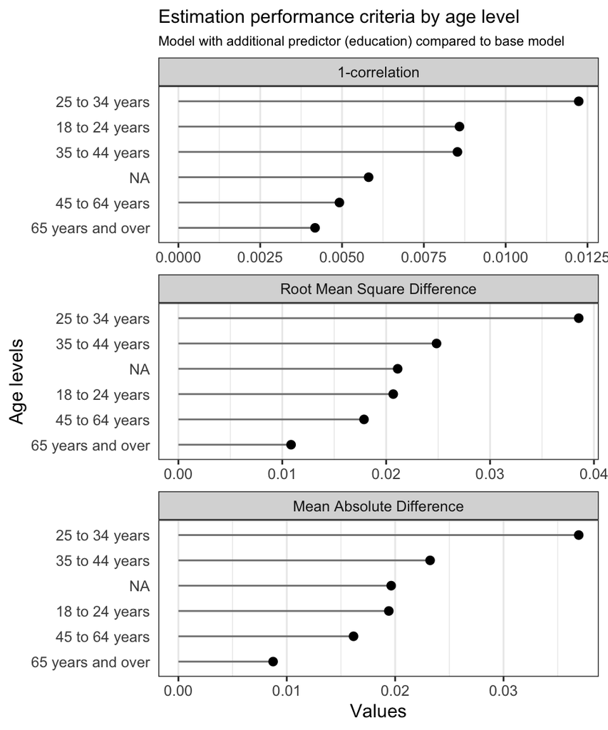

```r
get_metrics_plot(age_metrics,
                 "Estimation performance criteria by age level",
                 "Model with additional predictor (education) compared to base model",
                 "Age levels")
```

```r
age_metrics2_tmp <- left_join(mrp_age_state_fit1, mrp_age_state_fit3, by = c("state", "age"),
                     suffix = c("_fit1", "_fit3")) %>%
  group_by(age) %>%
  summarise(cor_adj = 1 - cor(median_fit1, median_fit3),
            mae = mae(median_fit1, median_fit3),
            rmse = rmse(median_fit1, median_fit3)) %>%
  pivot_longer(c(2:4), names_to = "metrics", values_to = "values") %>%
  rename(level = age)

age_metrics2 <- rbind(age_metrics2_tmp, metrics_fit1_fit3) %>%
  mutate(metrics = factor(metrics, levels = c("cor_adj", "rmse", "mae", "ci_len")),
         level = factor(level, levels = c("18 to 24 years", "25 to 34 years",
                                      "35 to 44 years", "45 to 64 years",
                                      "65 years and over", "Total")))
```

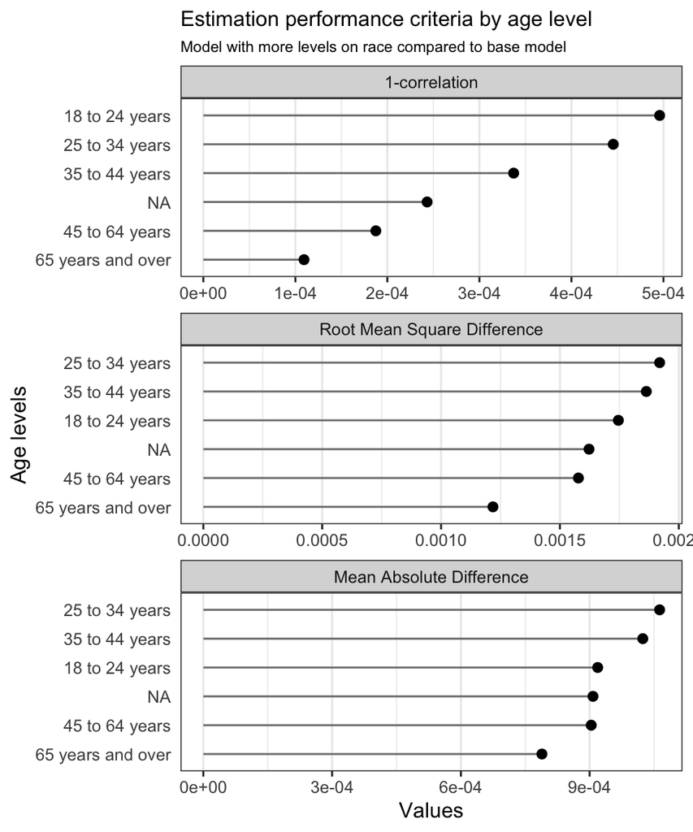

```r
get_metrics_plot(age_metrics2,
                 "Estimation performance criteria by age level",
                 "Model with more levels on race compared to base model",
                 "Age levels")
```

# Compare the length of credible interval

```r
# function to get the plot

metrics_ci_label <- c(`mean_ratio` = "Mean of CI length ratio",
                   `mean_ci_dev` = "Mean of CI length difference")

get_ci_plot <- function(data, level, title, subtitle, xlab){
  plot <- data %>%
  mutate(level = reorder(level, values)) %>%
  group_by(metrics, level) %>%
  arrange(desc(values)) %>%
  ungroup() %>%
  mutate(level = factor(paste(level, metrics, sep = "__"),
                       levels = rev(paste(level, metrics, sep = "__")))) %>%
  ggplot(aes(level, values)) +
  geom_segment(aes(xend = level, yend = 0),
               colour = "grey50") +
  geom_point(size = 2) +
  ggtitle(title,
          subtitle = subtitle) +
  facet_wrap(~metrics, scales = "free", ncol = 2,
             labeller = as_labeller(metrics_ci_label)) +
  scale_x_discrete(labels = function(x) gsub("__.+$", "", x)) +
  coord_flip() +
  scale_colour_brewer(palette = "Dark2") +
  theme_bw() +
  xlab(xlab) +
  ylab("Values") +
  theme(panel.grid.major.y = element_blank()) +
  theme(legend.position = "none",
              axis.ticks.y = element_blank(),
        plot.title = element_text(size = 11),
        plot.subtitle = element_text(size = 9))
  return(plot)
}
```

## race categories

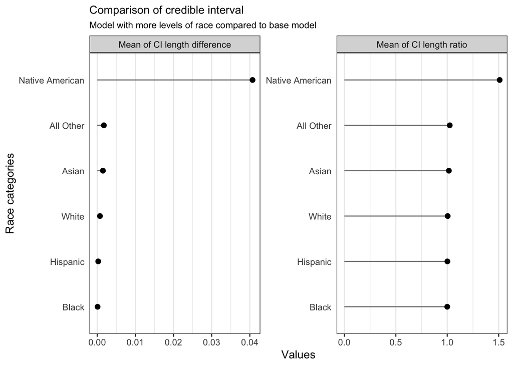

```r
compare_ci_len_race <- left_join(mrp_race_state_fit1, mrp_race_state_fit3, by = c("state", "original_re"),
                            suffix = c("_fit1", "_fit3")) %>%
  mutate(ci_len_ratio = ci_len_fit3/ci_len_fit1,
         ci_dev = ci_len_fit3 - ci_len_fit1) %>%
  group_by(original_re) %>%
  summarise(mean_ratio = mean(ci_len_ratio),
            mean_ci_dev = mean(ci_dev)) %>%
  pivot_longer(c(2:3), names_to = "metrics", values_to = "values")

get_ci_plot(compare_ci_len_race, compare_ci_len_race$original_re, "Comparison of credible interval",
            "Model with more levels of race compared to base model",
            "Race categories")
```

## Education

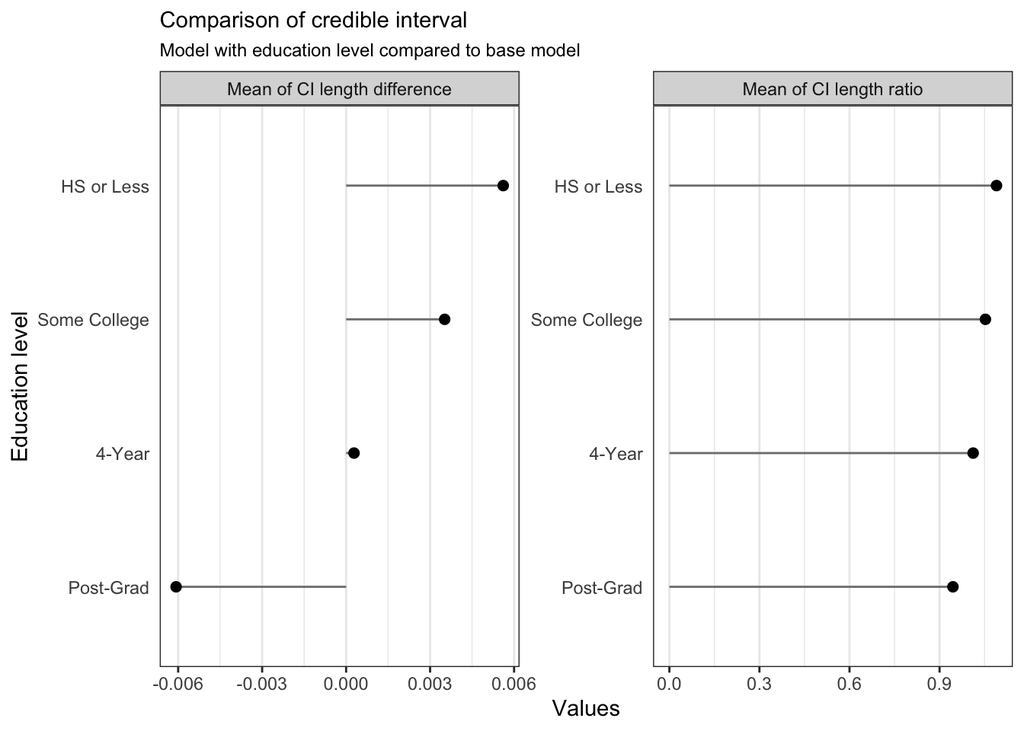

```r
compare_ci_len_ed <- left_join(mrp_educ_state_fit1, mrp_educ_state_fit2, by = c("state", "education"),
                            suffix = c("_fit1", "_fit2")) %>%
  mutate(ci_len_ratio = ci_len_fit2/ci_len_fit1,
         ci_dev = ci_len_fit2 - ci_len_fit1) %>%
  group_by(education) %>%
  summarise(mean_ratio = mean(ci_len_ratio),
            mean_ci_dev = mean(ci_dev)) %>%
  pivot_longer(c(2:3), names_to = "metrics", values_to = "values")

get_ci_plot(compare_ci_len_ed, compare_ci_len_ed$education, "Comparison of credible interval",
            "Model with education level compared to base model",
            "Education level")
```

# Age (fit3 vs base model)

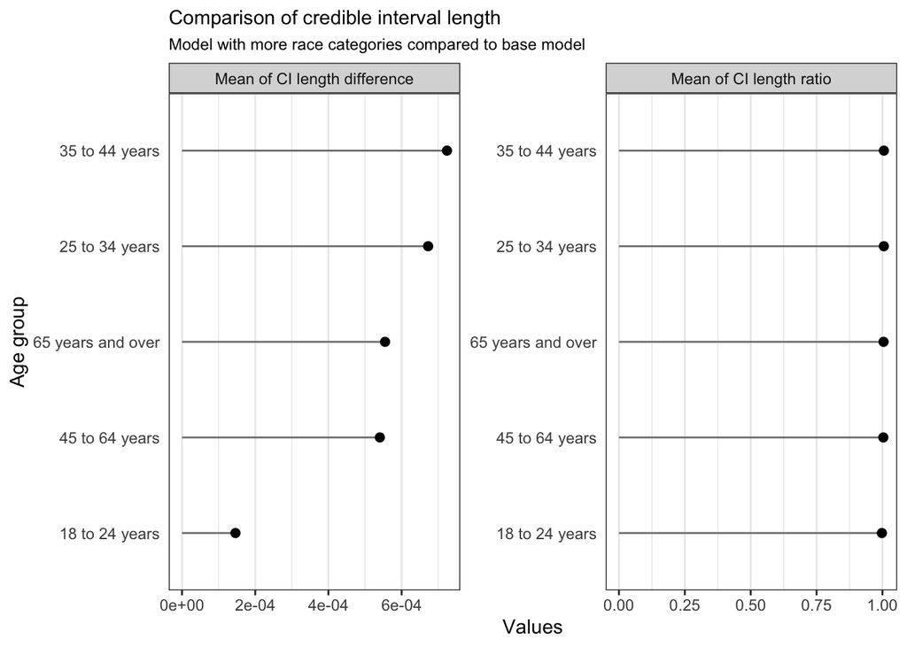

```r
compare_ci_len_age3 <- left_join(mrp_age_state_fit1, mrp_age_state_fit3, by = c("state", "age"),
                            suffix = c("_fit1", "_fit3")) %>%
  mutate(ci_len_ratio = ci_len_fit3/ci_len_fit1,
         ci_dev = ci_len_fit3 - ci_len_fit1) %>%
  group_by(age) %>%
  summarise(mean_ratio = mean(ci_len_ratio),
            mean_ci_dev = mean(ci_dev)) %>%
  pivot_longer(c(2:3), names_to = "metrics", values_to = "values")

get_ci_plot(compare_ci_len_age3, compare_ci_len_age3$age, "Comparison of credible interval length",
            "Model with more race categories compared to base model",
            "Age group")
```

# Age (fit2 vs base model)

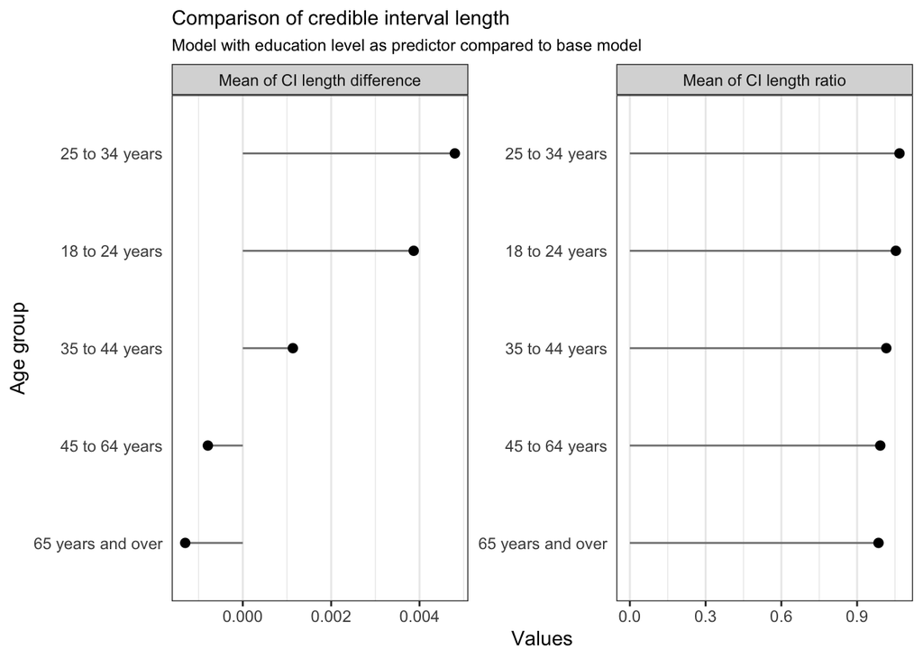

```r
compare_ci_len_age2 <- left_join(mrp_age_state_fit1, mrp_age_state_fit2, by = c("state", "age"),
                            suffix = c("_fit1", "_fit2")) %>%
  mutate(ci_len_ratio = ci_len_fit2/ci_len_fit1,
         ci_dev = ci_len_fit2 - ci_len_fit1) %>%
  group_by(age) %>%
  summarise(mean_ratio = mean(ci_len_ratio),
            mean_ci_dev = mean(ci_dev)) %>%
  pivot_longer(c(2:3), names_to = "metrics", values_to = "values")

get_ci_plot(compare_ci_len_age2, compare_ci_len_age2$age, "Comparison of credible interval length",
            "Model with education level as predictor compared to base model",
            "Age group")
```

# Extra plot (don’t need it)

```r
library(ggstance)
ggplot(mrp_race_state_fit3, aes(x = mean, y = state, color = original_re, xmin = mean-sd, xmax = mean+sd)) +
  geom_point(position = position_dodgev(height = .5)) +
  ylab("") +
  xlab("MRP estimates - probability of vote for Trump") +
  labs(color = "race") +
  geom_errorbarh(position = position_dodgev(height = .5),
                 alpha = 0.5)
```

Note:

1. Write clearly that the model that the comparison is between 2 models, and not compare to ground truth, so we can not interpret RMSE as the way we used to intreprete it.
2. Make separate plots for each metrics, so there is no misinterpretation abou the scale direction.

Next goal:

1. Create the plot of predictors in y axis and correlation between levels of predictors in x axis. (on going)
2. Create violin plots with estimates in y-axis and x-axis would be each levels of the race/education/age (race education (yes), age (compare base & fit2, base & fit3))
3. Create dot plots with estimates in y-axis and x-axis would be each levels of the race/education/age (?)
4. Create the scatter-plots ground truth vs estimates from base model, modelb, and modelc, and facet it (done)
5. The subsection would be: the states comparison, the model comparison, interrogating the model with the ground truth.
6. weighted estimates* vs mrp estimates vs ground truth
7. Also shows the mean absolute deviation between the base model and the other models. (yes)
8. The scatter should also shows the RMSE.(yes)

Next goal:

## Use the g2016 for the ground truth

## Replicate the plot:

1. State on the y-axis and mrp-estimate on the x-axis / choropleth map
2. Scatter plot between MRP estimate and ground truth
3. Comparison between the 3 outcomes
4. Comparison between the different predictors (original re, collapsed re, and education)

Next: 3. Scatter plot between MRP estimate and direct estimate (to get the uncertainty use the survey package) survey::svydesign(ids=~1, weight = “w in original data frame”, mean) mean = survey::surveymean 4. plot the MRP estimate with the performance criteria (MSE) 7. Descriptive statistic about the obs using in the model (i.e., the n vote trump, not vote, and missing for the 3 outcomes) 8. Check again the levels in the outcome.